# 03 - Linear Regression

# Linear Regression

## Model Assumptions & Diagnostics

We now check assumptions and common diagnostics for a linear model.

**What we’ll examine**

- **Linearity** of relationships (component + residual plots)
- **Normality** of residuals (QQ plot)
- **Homoscedasticity** (residuals vs fitted; Breusch–Pagan test)
- **Multicollinearity** (VIF)
- **Influential points** (leverage, Cook’s distance)

*Note:* Independence is usually a **design** issue. If data are not time-series/clustered, we assume iid.

### Augmented residual data

```r
lm_model <- lm(
  bodyfat ~ weight + abdomen + forearm + wrist,
  data = bf_df)
aug <- augment(lm_model) %>% # augment gives us a lot of statistics that are useful.
  mutate(.stdres = rstandard(lm_model))  # standardized residuals

head(aug)
```

| bodyfat | weight | abdomen | forearm | wrist | .fitted | .resid | .hat | .sigma | .cooksd | .std.resid | .stdres |
| --- | --- | --- | --- | --- | --- | --- | --- | --- | --- | --- | --- |
| 12.3 | 154.25 | 85.2 | 27.4 | 17.1 | 16.27592 | -3.975917 | 0.0098686 | 4.344078 | 0.0016875 | -0.9200865 | -0.9200865 |
| 6.1 | 173.25 | 83.0 | 28.9 | 18.2 | 10.56154 | -4.461541 | 0.0137573 | 4.342105 | 0.0029857 | -1.0345006 | -1.0345006 |
| 25.3 | 154.00 | 87.9 | 25.2 | 16.6 | 18.71069 | 6.589308 | 0.0236543 | 4.330721 | 0.0114258 | 1.5355916 | 1.5355916 |
| 10.4 | 184.75 | 86.4 | 29.4 | 18.2 | 12.62380 | -2.223798 | 0.0153779 | 4.349195 | 0.0008319 | -0.5160577 | -0.5160577 |
| 28.7 | 184.25 | 100.0 | 27.7 | 17.7 | 26.18263 | 2.517365 | 0.0133806 | 4.348541 | 0.0009238 | 0.5835918 | 0.5835918 |
| 20.9 | 210.25 | 94.4 | 30.6 | 18.8 | 16.79538 | 4.104616 | 0.0206110 | 4.343500 | 0.0038392 | 0.9550645 | 0.9550645 |

### 1) Linearity: Component + Residual (Partial Residual) Plots

If relationships are strongly curved, consider transformations or adding terms (splines, polynomials).

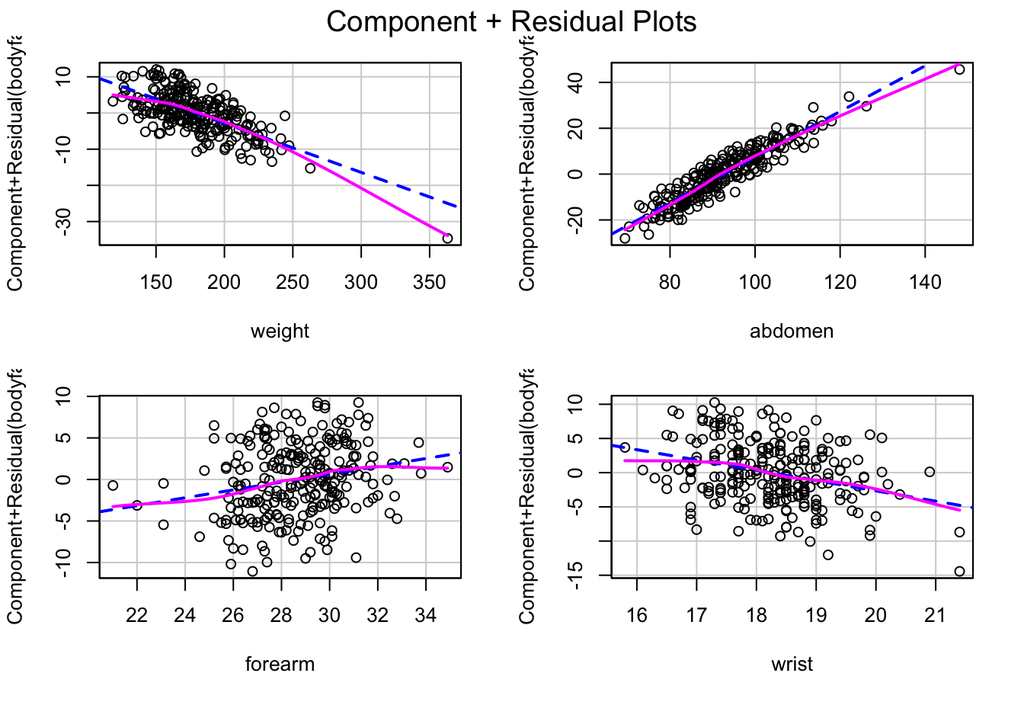

```r
car::crPlots(lm_model)  # opens a panel of C+R plots
```

### 2) Normality of Residuals (Primarily for CIs/p-values)

For prediction, normality is less critical than calibration and unbiasedness, but we inspect QQ plot.

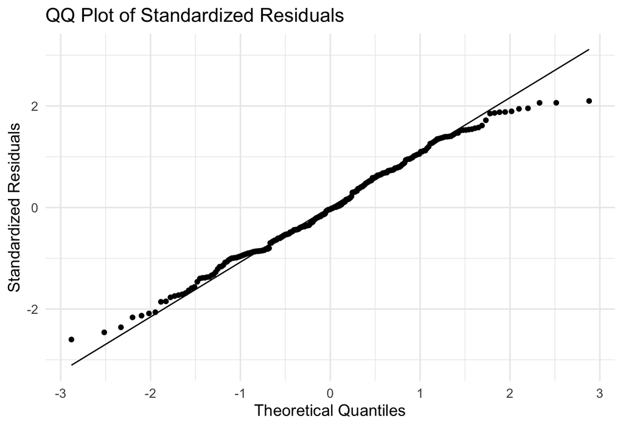

```r
ggplot(aug, aes(sample = .stdres)) +
  stat_qq() + stat_qq_line() +
  labs(title = "QQ Plot of Standardized Residuals",
       x = "Theoretical Quantiles", y = "Standardized Residuals") +
  theme_minimal(base_size = 13)
```

*(You can also run a Shapiro–Wilk test for small $n$: `shapiro.test(residuals(lm_model))`.)*

### 3) Homoscedasticity (Constant Error Variance)

Look for funnel shapes; the red LOESS line should be roughly flat.

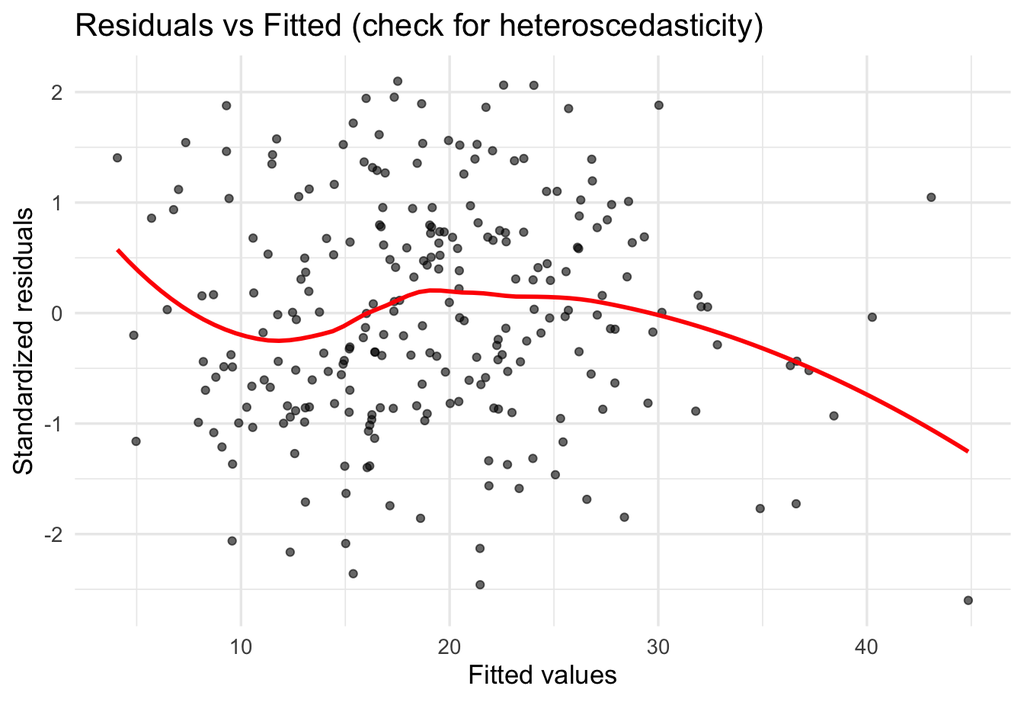

```r
ggplot(aug, aes(.fitted, .stdres)) +
  geom_point(alpha = 0.6) +
  geom_smooth(se = FALSE, color = "red") +
  labs(x = "Fitted values", y = "Standardized residuals",
       title = "Residuals vs Fitted (check for heteroscedasticity)") +
  theme_minimal(base_size = 13)
```

Formal test: **Breusch–Pagan**

```r
lmtest::bptest(lm_model)
```

```
##
##  studentized Breusch-Pagan test
##
## data:  lm_model
## BP = 2.1249, df = 4, p-value = 0.7128
```

If significant, consider variance-stabilizing transforms (e.g., transform response), robust SEs, or modeling heteroscedasticity.

### 4) Multicollinearity (VIF)

High VIFs (> 5–10) suggest unstable coefficients.

```r
car::vif(lm_model) %>% sort(decreasing = TRUE)
```

```
##   weight  abdomen    wrist  forearm
## 7.040774 4.864380 2.273047 1.793374
```

If problematic: consider removing/redefining variables, combining related measures, or penalized regression.

### 5) Influence: Leverage & Cook’s Distance

Identify points that overly influence the fit.

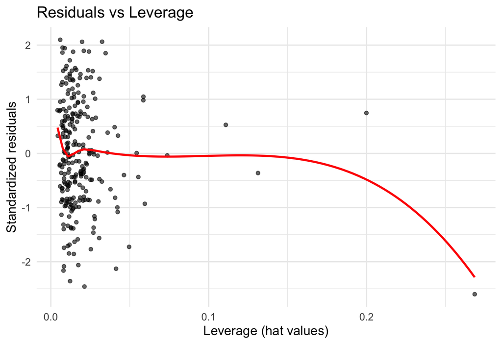

```r
ggplot(aug, aes(.hat, .stdres)) +
  geom_point(alpha = 0.6) +
  geom_smooth(se = FALSE, color = "red") +
  labs(x = "Leverage (hat values)", y = "Standardized residuals",
       title = "Residuals vs Leverage") +
  theme_minimal(base_size = 13)
```

```r
# Top potentially influential points by Cook's D
aug %>%
  mutate(cook = .cooksd) %>%
  arrange(desc(cook)) %>%
  slice_head(n = 10) %>%
  dplyr::select(.fitted, .stdres, .hat, cook) %>%
  kable(digits = 3, caption = "Top 10 observations by Cook's distance")
```

Top 10 observations by Cook’s distance

| .fitted | .stdres | .hat | cook |
| --- | --- | --- | --- |
| 44.858 | -2.600 | 0.268 | 0.496 |
| 21.456 | -2.130 | 0.041 | 0.039 |
| 36.607 | -1.726 | 0.050 | 0.031 |
| 22.587 | 2.063 | 0.032 | 0.029 |
| 22.399 | 0.747 | 0.200 | 0.028 |
| 21.463 | -2.459 | 0.021 | 0.026 |
| 25.702 | 1.851 | 0.035 | 0.025 |
| 30.030 | 1.881 | 0.024 | 0.018 |
| 24.037 | 2.061 | 0.020 | 0.017 |
| 34.885 | -1.769 | 0.025 | 0.016 |

Let’s look at the data for the person with the largest Cook’s distance.

```r
aug%>%
  mutate(cook = .cooksd) %>%
  arrange(desc(cook)) %>%
  slice_head(n = 1) %>%
  dplyr::select(bodyfat:.resid)
```

| bodyfat | weight | abdomen | forearm | wrist | .fitted | .resid |
| --- | --- | --- | --- | --- | --- | --- |
| 35.2 | 363.15 | 148.1 | 29 | 21.4 | 44.85803 | -9.658034 |

> If you remove an influential point, always **refit, compare, and justify**—don’t auto-drop.

## Model Selection

### Best Subset Selection

We perform best subset selection by fitting a separate least-squares regression for each combination of the $p$ predictors. The `regsubsets()` function identifies the best model of size $k$ (quantified via RSS).

```r
best_subset <- regsubsets(bodyfat ~ ., bf_df, nvmax = 10)
results <- summary(best_subset)

# quick peek at coefficients for an 8-predictor model
round(coef(best_subset, id = 8), 4)
```

```
## (Intercept)         age      weight        neck     abdomen         hip
##    -22.6564      0.0658     -0.0899     -0.4666      0.9448     -0.1954
##       thigh     forearm       wrist
##      0.3024      0.5157     -1.5367
```

To choose the number of predictors $k$, we can compare common criteria.

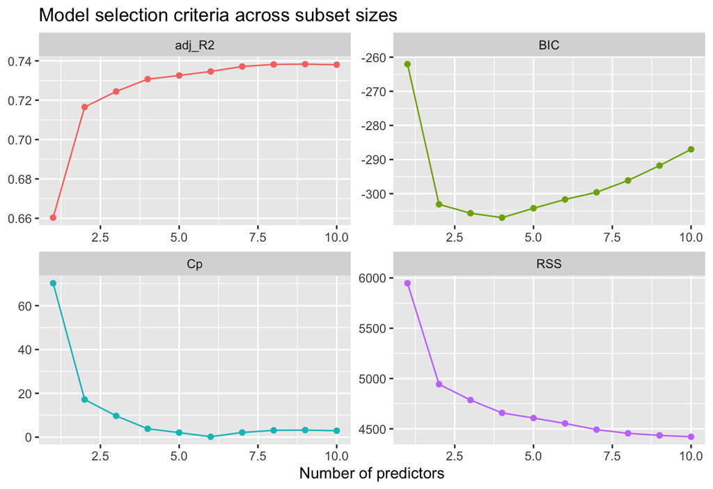

```r
summ_results <- tibble(
  predictors = 1:10,
  adj_R2 = results$adjr2,
  Cp     = abs(results$cp - 2:11), # Want Cp to be close to p+1
  BIC    = results$bic,
  RSS    = results$rss
)

summ_results %>%
  pivot_longer(-predictors, names_to = "stat", values_to = "value") %>%
  ggplot(aes(predictors, value, color = stat)) +
  geom_line(show.legend = FALSE) +
  geom_point(show.legend = FALSE) +
  facet_wrap(~ stat, scales = "free") +
  labs(x = "Number of predictors", y = NULL,
       title = "Model selection criteria across subset sizes")
```

```r
summ_results %>% kable(digits = 3)
```

| predictors | adj_R2 | Cp | BIC | RSS |
| --- | --- | --- | --- | --- |
| 1 | 0.660 | 70.243 | -262.044 | 5947.463 |
| 2 | 0.717 | 17.171 | -303.120 | 4943.245 |
| 3 | 0.724 | 9.707 | -305.734 | 4786.054 |
| 4 | 0.731 | 3.824 | -307.026 | 4658.236 |
| 5 | 0.733 | 2.075 | -304.274 | 4607.169 |
| 6 | 0.735 | 0.186 | -301.697 | 4553.520 |
| 7 | 0.737 | 2.135 | -299.603 | 4491.849 |
| 8 | 0.738 | 3.101 | -296.131 | 4455.324 |
| 9 | 0.738 | 3.217 | -291.776 | 4434.613 |
| 10 | 0.738 | 2.932 | -287.003 | 4421.330 |

#### Choose a Final Model (from Best Subsets)

By default here, we’ll select the model that **minimizes BIC** (you can swap to adj.$R^2$ or $C_p$ if you prefer).

```r
k_bic <- summ_results %>% slice_min(BIC, n = 1) %>% pull(predictors)
k_bic
```

```
## [1] 4
```

We’ll extract the chosen model’s variables and refit an `lm` so we can do diagnostics easily.

```r
coef_chosen <- coef(best_subset, id = k_bic)
vars_chosen <- names(coef_chosen)[-1]   # drop intercept

form_chosen <- as.formula(
  paste("bodyfat ~", paste(vars_chosen, collapse = " + "))
)
form_chosen
```

```
## bodyfat ~ weight + abdomen + forearm + wrist
```

```r
mod_final <- lm(form_chosen, data = bf_df)
summary(mod_final)
```

```
##
## Call:
## lm(formula = form_chosen, data = bf_df)
##
## Residuals:
##      Min       1Q   Median       3Q      Max
## -10.5626  -3.1235  -0.1461   3.1313   9.0867
##
## Coefficients:
##              Estimate Std. Error t value Pr(>|t|)
## (Intercept) -34.85407    7.24500  -4.811 2.62e-06 ***
## weight       -0.13563    0.02475  -5.480 1.05e-07 ***
## abdomen       0.99575    0.05607  17.760  < 2e-16 ***
## forearm       0.47293    0.18166   2.603 0.009790 **
## wrist        -1.50556    0.44267  -3.401 0.000783 ***
## ---
## Signif. codes:  0 '***' 0.001 '**' 0.01 '*' 0.05 '.' 0.1 ' ' 1
##
## Residual standard error: 4.343 on 247 degrees of freedom
## Multiple R-squared:  0.735,  Adjusted R-squared:  0.7307
## F-statistic: 171.3 on 4 and 247 DF,  p-value: < 2.2e-16
```

### Automated Model Selection Procedures

#### Forward and Backward (AIC)

```r
bf_mod  <- lm(bodyfat ~ ., data = bf_df)
back_mf <- stepAIC(bf_mod, direction = "backward")
```

```
## Start:  AIC=749.85
## bodyfat ~ age + weight + height + neck + chest + abdomen + hip +
##     thigh + knee + ankle + biceps + forearm + wrist
##
##           Df Sum of Sq    RSS    AIC
## - knee     1      0.06 4420.1 747.85
## - chest    1      0.51 4420.6 747.88
## - height   1      1.12 4421.2 747.91
## - ankle    1     11.86 4431.9 748.52
## - biceps   1     20.74 4440.8 749.03
## - hip      1     31.51 4451.6 749.64
## <none>                 4420.1 749.85
## - weight   1     45.10 4465.2 750.41
## - thigh    1     53.61 4473.7 750.89
## - age      1     74.72 4494.8 752.07
## - neck     1     75.66 4495.7 752.13
## - forearm  1     97.11 4517.2 753.33
## - wrist    1    178.85 4598.9 757.84
## - abdomen  1   2083.46 6503.5 845.17
##
## Step:  AIC=747.85
## bodyfat ~ age + weight + height + neck + chest + abdomen + hip +
##     thigh + ankle + biceps + forearm + wrist
##
##           Df Sum of Sq    RSS    AIC
## - chest    1      0.52 4420.6 745.88
## - height   1      1.06 4421.2 745.91
## - ankle    1     12.59 4432.7 746.57
## - biceps   1     20.68 4440.8 747.03
## - hip      1     31.47 4451.6 747.64
## <none>                 4420.1 747.85
## - weight   1     45.26 4465.4 748.42
## - thigh    1     60.46 4480.6 749.28
## - neck     1     77.09 4497.2 750.21
## - age      1     80.99 4501.1 750.43
## - forearm  1     98.18 4518.3 751.39
## - wrist    1    179.35 4599.5 755.88
## - abdomen  1   2083.40 6503.5 843.17
##
## Step:  AIC=745.88
```

[output cut: 49 more lines]

```
##
## Step:  AIC=741.85
## bodyfat ~ age + weight + neck + abdomen + hip + thigh + forearm +
##     wrist
##
##           Df Sum of Sq    RSS    AIC
## <none>                 4455.3 741.85
## - hip      1      36.5 4491.8 741.91
## - neck     1      79.1 4534.4 744.29
## - age      1      83.8 4539.1 744.55
## - weight   1      93.0 4548.3 745.05
## - thigh    1     100.7 4556.0 745.48
## - forearm  1     140.5 4595.8 747.67
## - wrist    1     166.8 4622.2 749.12
## - abdomen  1    3163.0 7618.3 875.04
```

```r
for_mf  <- stepAIC(bf_mod, direction = "forward", trace = 0)

back_mf$coefficients
```

```
##  (Intercept)          age       weight         neck      abdomen          hip
## -22.65637291   0.06577964  -0.08985290  -0.46655783   0.94481514  -0.19543492
##        thigh      forearm        wrist
##   0.30239157   0.51572117  -1.53665172
```

```r
for_mf$coefficients
```

```
##  (Intercept)          age       weight       height         neck        chest
## -21.35323494   0.06457350  -0.09638287  -0.04393895  -0.47546758  -0.01718468
##      abdomen          hip        thigh         knee        ankle       biceps
##   0.95499717  -0.18858604   0.24834935   0.01394629   0.17788488   0.18230087
##      forearm        wrist
##   0.45573774  -1.65449992
```

### Forward-Stagewise Regression

#### Manual Stagewise Illustration

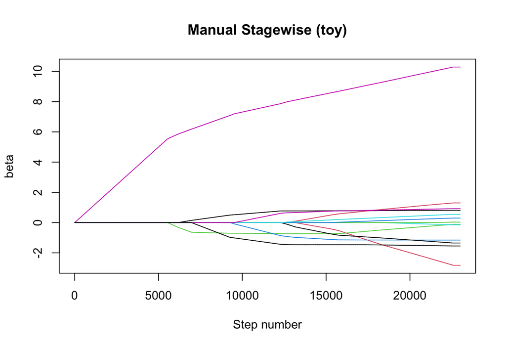

```r
y <- bf_df$bodyfat
M <- as.matrix(bf_df[,-1])

# center/scale
y <- y - mean(y)
M <- scale(M)

beta <- matrix(0, ncol = ncol(M), nrow = 1)
r    <- y
eps  <- 0.001
lots <- 23000

for(i in 1:lots){
  co <- t(M) %*% r
  j  <- (1:ncol(M))[abs(co) == max(abs(co))][1]
  delta <- eps * sign(co[j])
  b <- beta[nrow(beta),]
  b[j] <- b[j] + delta
  beta <- rbind(beta, b)
  r <- r - delta * M[, j]
}

matplot(beta, type = "l", lty = 1, xlab = "Step number", ylab = "beta",
        main = "Manual Stagewise (toy)")
```

```r
beta_mat <- rbind(beta[c(1, seq(5000, 20000, 5000), lots),])
colnames(beta_mat) <- colnames(M)
rownames(beta_mat) <- c(1, seq(5000, 20000, 5000), lots)
round(beta_mat, 2)
```

|  | age | weight | height | neck | chest | abdomen | hip | thigh | knee | ankle | biceps | forearm | wrist |
| --- | --- | --- | --- | --- | --- | --- | --- | --- | --- | --- | --- | --- | --- |
| 1 | 0.00 | 0.00 | 0.00 | 0.00 | 0.00 | 0.00 | 0.00 | 0.00 | 0.00 | 0.0 | 0.00 | 0.00 | 0.00 |
| 5000 | 0.00 | 0.00 | 0.00 | 0.00 | 0.00 | 5.00 | 0.00 | 0.00 | 0.00 | 0.0 | 0.00 | 0.00 | 0.00 |
| 10000 | 0.56 | 0.00 | -0.71 | -0.22 | 0.00 | 7.31 | 0.00 | 0.00 | 0.00 | 0.0 | 0.00 | 0.11 | -1.09 |
| 15000 | 0.78 | -0.36 | -0.74 | -1.10 | 0.00 | 8.52 | -0.69 | 0.45 | 0.00 | 0.0 | 0.16 | 0.75 | -1.46 |
| 20000 | 0.80 | -1.99 | -0.34 | -1.15 | -0.06 | 9.68 | -1.15 | 1.04 | 0.00 | 0.2 | 0.42 | 0.86 | -1.50 |
| 23000 | 0.82 | -2.82 | -0.12 | -1.16 | -0.15 | 10.29 | -1.35 | 1.30 | 0.03 | 0.3 | 0.55 | 0.92 | -1.54 |

#### Stagewise via the `lars` function

```r
ForStag_mf <- lars(as.matrix(bf_df[,-1]), bf_df$bodyfat,
                   type = "forward.stagewise", trace = TRUE)
```

```
## Forward Stagewise sequence
## Computing X'X .....
## LARS Step 1 :     Variable 6     added
## LARS Step 2 :     Variable 3     added
## LARS Step 3 :     Variable 1     added
## LARS Step 4 :     Variable 13    added
## LARS Step 5 :     Variable 4     added
## LARS Step 6 :     Variable 12    added
## LARS Step 7 :     Variable 7     added
## NNLS Step:    Variable 3     dropped
## NNLS Step:    Variable 1     dropped
## LARS Step 8 :     Variable 11    added
## LARS Step 9 :     Variable 8     added
## LARS Step 10 :    Variable 2     added
## NNLS Step:    Variable 13    dropped
## LARS Step 11 :    Variable 1     added
## LARS Step 12 :    Variable 10    added
## LARS Step 13 :    Variable 3     added
## LARS Step 14 :    Variable 13    added
## LARS Step 15 :    Variable 5     added
## LARS Step 16 :    Variable 9     added
## NNLS Step:    Variable 4     dropped
## LARS Step 17 :    Variable 4     added
## NNLS Step:    Variable 1     dropped
## LARS Step 18 :    Variable 1     added
## Computing residuals, RSS etc .....
```

```r
print(ForStag_mf)
```

```
##
## Call:
## lars(x = as.matrix(bf_df[, -1]), y = bf_df$bodyfat, type = "forward.stagewise",
##     trace = TRUE)
## R-squared: 0.749
## Sequence of Forward Stagewise moves:
##      abdomen height age wrist neck forearm hip height age biceps thigh weight
## Var        6      3   1    13    4      12   7     -3  -1     11     8      2
## Step       1      2   3     4    5       6   7      7   7      8     9     10
##      wrist age ankle height wrist chest knee neck neck age age
## Var    -13   1    10      3    13     5    9   -4    4  -1   1
## Step    10  11    12     13    14    15   16   16   17  17  18
```

```r
round(coef(ForStag_mf), 2)
```

| age | weight | height | neck | chest | abdomen | hip | thigh | knee | ankle | biceps | forearm | wrist |
| --- | --- | --- | --- | --- | --- | --- | --- | --- | --- | --- | --- | --- |
| 0.00 | 0.00 | 0.00 | 0.00 | 0.00 | 0.00 | 0.00 | 0.00 | 0.00 | 0.00 | 0.00 | 0.00 | 0.00 |
| 0.00 | 0.00 | 0.00 | 0.00 | 0.00 | 0.51 | 0.00 | 0.00 | 0.00 | 0.00 | 0.00 | 0.00 | 0.00 |
| 0.00 | 0.00 | -0.12 | 0.00 | 0.00 | 0.54 | 0.00 | 0.00 | 0.00 | 0.00 | 0.00 | 0.00 | 0.00 |
| 0.01 | 0.00 | -0.24 | 0.00 | 0.00 | 0.57 | 0.00 | 0.00 | 0.00 | 0.00 | 0.00 | 0.00 | 0.00 |
| 0.04 | 0.00 | -0.27 | 0.00 | 0.00 | 0.66 | 0.00 | 0.00 | 0.00 | 0.00 | 0.00 | 0.00 | -1.05 |
| 0.04 | 0.00 | -0.27 | -0.03 | 0.00 | 0.67 | 0.00 | 0.00 | 0.00 | 0.00 | 0.00 | 0.00 | -1.08 |
| 0.06 | 0.00 | -0.28 | -0.36 | 0.00 | 0.73 | 0.00 | 0.00 | 0.00 | 0.00 | 0.00 | 0.30 | -1.54 |
| 0.06 | 0.00 | -0.28 | -0.36 | 0.00 | 0.73 | 0.00 | 0.00 | 0.00 | 0.00 | 0.00 | 0.31 | -1.55 |
| 0.06 | 0.00 | -0.28 | -0.38 | 0.00 | 0.74 | -0.02 | 0.00 | 0.00 | 0.00 | 0.01 | 0.32 | -1.56 |
| 0.06 | 0.00 | -0.28 | -0.40 | 0.00 | 0.75 | -0.04 | 0.02 | 0.00 | 0.00 | 0.02 | 0.33 | -1.57 |
| 0.06 | 0.00 | -0.28 | -0.42 | 0.00 | 0.76 | -0.06 | 0.04 | 0.00 | 0.00 | 0.03 | 0.34 | -1.57 |
| 0.06 | -0.01 | -0.28 | -0.46 | 0.00 | 0.80 | -0.11 | 0.10 | 0.00 | 0.00 | 0.06 | 0.37 | -1.57 |
| 0.06 | -0.02 | -0.28 | -0.47 | 0.00 | 0.81 | -0.12 | 0.11 | 0.00 | 0.02 | 0.07 | 0.38 | -1.57 |
| 0.06 | -0.04 | -0.23 | -0.47 | 0.00 | 0.84 | -0.13 | 0.14 | 0.00 | 0.05 | 0.09 | 0.40 | -1.57 |
| 0.06 | -0.05 | -0.19 | -0.47 | 0.00 | 0.86 | -0.14 | 0.16 | 0.00 | 0.08 | 0.11 | 0.41 | -1.58 |
| 0.06 | -0.08 | -0.09 | -0.48 | -0.01 | 0.92 | -0.17 | 0.22 | 0.00 | 0.14 | 0.16 | 0.44 | -1.63 |
| 0.06 | -0.10 | -0.04 | -0.48 | -0.02 | 0.95 | -0.19 | 0.25 | 0.01 | 0.18 | 0.18 | 0.46 | -1.65 |
| 0.06 | -0.10 | -0.04 | -0.48 | -0.02 | 0.95 | -0.19 | 0.25 | 0.01 | 0.18 | 0.18 | 0.46 | -1.65 |
| 0.06 | -0.10 | -0.04 | -0.48 | -0.02 | 0.95 | -0.19 | 0.25 | 0.01 | 0.18 | 0.18 | 0.46 | -1.65 |

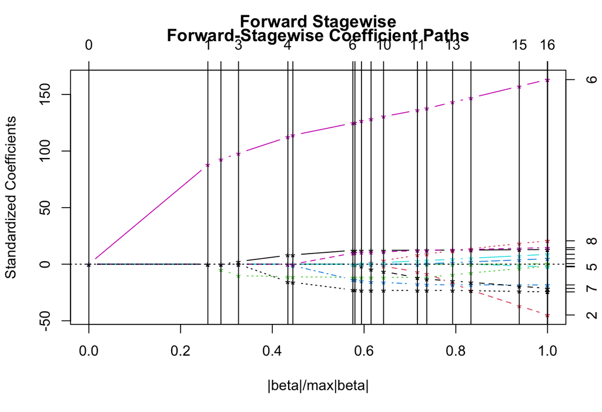

```r
plot(ForStag_mf, main = "Forward-Stagewise Coefficient Paths")
```

#### Stagewise with CV via the `cv.lars` function

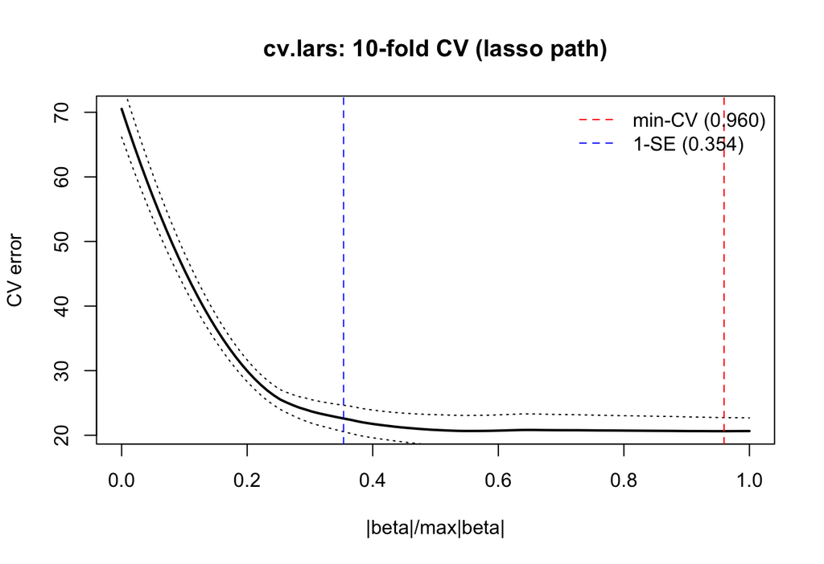

```r
X <- as.matrix(bf_df[,-1])
y <- bf_df$bodyfat

# 2) K-fold CV along that path (K = 10 here)
set.seed(735794)
cv_out <- cv.lars(X, y, K = 10, type = "forward.stagewise", plot.it = FALSE, se = TRUE)

# The CV object contains:
# cv_out$cv        -> mean CV error at each fraction
# cv_out$cv.error  -> (approx) SE of CV error at each fraction
# cv_out$index     -> Abscissa values at which the CV curve is be computed. If mode="fraction" this is the fraction of the saturated |beta|.

# 3) Pick tuning by minimum CV
i_min <- which.min(cv_out$cv)
frac_min <- cv_out$index[i_min]

# 1-SE rule: pick the simplest (largest shrinkage / smaller fraction)
# whose CV error <= cv_min + SE_min.
cv_min <- cv_out$cv[i_min]
se_min <- cv_out$cv.error[i_min]
target <- cv_min + se_min

# Among all fractions with CV <= target, pick the *smallest* index that
# still satisfies this (for lars' fraction scale, smaller fraction = less variables in the model).
i_1se <- min(which(cv_out$cv <= target))
frac_1se <- cv_out$index[i_1se]

# 4) Inspect / plot the CV curve
plot(cv_out$index, cv_out$cv, type = "l", lwd = 2,
     xlab = "|beta|/max|beta|", ylab = "CV error",
     main = "cv.lars: 10-fold CV (lasso path)")
lines(cv_out$index, cv_out$cv + cv_out$cv.error, lty = 3)
lines(cv_out$index, cv_out$cv - cv_out$cv.error, lty = 3)
abline(v = c(frac_min, frac_1se), col = c("red","blue"), lty = 2)
legend("topright",
       c(sprintf("min-CV (%.3f)", frac_min),
         sprintf("1-SE (%.3f)", frac_1se)),
       col = c("red","blue"), lty = 2, bty = "n")
```

```r
# 5) Coefficients at chosen fraction (min-CV shown; use frac_1se similarly)
coef_min <- predict(ForStag_mf, s = frac_min, type = "coef", mode = "fraction")$coefficients
round(coef_min, 4)
```

```
##     age  weight  height    neck   chest abdomen     hip   thigh    knee   ankle
##  0.0643 -0.0850 -0.0773 -0.4757 -0.0131  0.9323 -0.1771  0.2294  0.0048  0.1547
##  biceps forearm   wrist
##  0.1648  0.4446 -1.6364
```

```r
coef_1se <- predict(ForStag_mf, s = frac_1se, type = "coef", mode = "fraction")$coefficients
round(coef_1se, 4)
```

```
##     age  weight  height    neck   chest abdomen     hip   thigh    knee   ankle
##  0.0188  0.0000 -0.2510  0.0000  0.0000  0.5948  0.0000  0.0000  0.0000  0.0000
##  biceps forearm   wrist
##  0.0000  0.0000 -0.2657
```

### Quick Wrap-Up

- We ran **diagnostics** on the model selected a linear model via **best subsets (BIC)**.
- If diagnostics flag issues (e.g., curvature, unequal variance, high VIF, influential points), iterate:
  - Transform features or response,
  - Add parsimonious nonlinearity (e.g., splines on 1–2 key terms),
  - Consider **penalized** linear models for stability.

*(In a later module we’ll revisit with cross-validation to report honest out-of-sample error and to compare against penalized methods.)*